# rRNA removal

01rRNA_removal.sh

```bash
#!/bin/bash
#Sort metatranscriptomic reads into rRNA and non-rRNA files

#Transfer the fasta file from gluster
cp $1 ./
name=$(basename $1 |cut -d'.' -f1)

#Unzip files
tar -xvf sortmerna-2.1-linux-64.tar.gz
gzip -d $name.fastq
cd sortmerna-2.1-linux-64

#Index the rRNA databases
./indexdb_rna --ref ./rRNA_databases/silva-bac-16s-id90.fasta,./index/silva-bac-16s-db:\./rRNA_databases/silva-bac-23s-id98.fasta,./index/silva-bac-23s-db:./rRNA_databases/silva-arc-16s-id95.fasta,./index/silva-arc-16s-db:./rRNA_databases/silva-arc-23s-id98.fasta,./index/silva-arc-23s-db:./rRNA_databases/silva-euk-18s-id95.fasta,./index/silva-euk-18s-db:./rRNA_databases/silva-euk-28s-id98.fasta,./index/silva-euk-28s:./rRNA_databases/rfam-5s-database-id98.fasta,./index/rfam-5s-db:./rRNA_databases/rfam-5.8s-database-id98.fasta,./index/rfam-5.8s-db

#Run the sorting program
./sortmerna --ref ./rRNA_databases/silva-bac-16s-id90.fasta,./index/silva-bac-16s-db:./rRNA_databases/silva-bac-23s-id98.fasta,./index/silva-bac-23s-db:./rRNA_databases/silva-arc-16s-id95.fasta,./index/silva-arc-16s-db:./rRNA_databases/silva-arc-23s-id98.fasta,./index/silva-arc-23s-db:./rRNA_databases/silva-euk-18s-id95.fasta,./index/silva-euk-18s-db:./rRNA_databases/silva-euk-28s-id98.fasta,./index/silva-euk-28s:./rRNA_databases/rfam-5s-database-id98.fasta,./index/rfam-5s-db:./rRNA_databases/rfam-5.8s-database-id98.fasta,./index/rfam-5.8s-db --reads ../${name}.fastq  --fastx --aligned ${name}_rRNA --other ${name}_nonrRNA --log -v -m 1 -a 1

#Let's unpack the parameters I've chosen. --ref refers to the databases I've just indexed. --reads says use the fastq file provided. --fastx means I would like a fastq file as output. --aligned is the name for rRNA reads, --other is the name for non-rRNA reads. --log says compute statistics about the run. -v means verbose. I've left the alignment setting at the default, --best. There's a faster setting, but I'm hoping I won't need it. And finally, -m tells sortmerna it can use 3GB of RAM to hold each piece of the fastq file as it processes. Hopefully that will give it a fighting chance.
#Move the output files back to gluster
mv ${name}_rRNA.fastq /mnt/gluster/amlinz/GEODES_rRNA_split/
mv ${name}_nonrRNA.fastq /mnt/gluster/amlinz/GEODES_nonrRNA_split/

#Remove files
cd ..
rm ${name}.fastq
rm sortmerna-2.1-linux-64.tar.gz
rm -r sortmerna-2.1-linux-64
```

3. Put everything back together. This is a pretty simple program - all it does it copy files generated from the same sample, concatenate them into a single file, count the number of lines, zip it up, and send it back to gluster.

```bash
# We'll be using samplenames.txt again as our reference file.

# Submit the jobs:
condor_submit submits/02cat_files.sub

# You'll get a file back in your home folder that has the number of lines in both the rRNA and nonrRNA files. Concatenate these into a single file:
cat *_rRNA_results.txt > GEODES_rRNA_ratios.txt
cat GEODES_rRNA_ratios.txt

# Check the output!
ls -ltr /mnt/gluster/amlinz/GEODES_nonrRNA_concat/
ls -ltr /mnt/gluster/amlinz/GEODES_rRNA_concat/

# Are the error files empty?
ls -ltr 02*.err
```

02cat_files.sub

```bash
# 02cat_files.sub
#
#
# Specify the HTCondor Universe
universe = vanilla
log = 02cat_files_$(Cluster).log
error = 02cat_files_$(Cluster)_$(Process).err
#
# Specify your executable, arguments, and a file for HTCondor to store standard
#  output.
executable = executables/02cat_files.sh
arguments = $(sample)
output = 02cat_files_$(Cluster).out
#
# Specify that HTCondor should transfer files to and from the
#  computer where each job runs.
should_transfer_files = YES
when_to_transfer_output = ON_EXIT
#transfer_input_files =
#transfer_output_files = $(sample)_rRNA_results.txt
#
# Tell HTCondor what amount of compute resources
#  each job will need on the computer where it runs.
Requirements = (Target.HasGluster == true)
request_cpus = 1
request_memory = 10GB
request_disk = 10GB
#
# Tell HTCondor to run every fastq file in the provided list:
queue sample from samplenames.txt
```

02cat_files.sh

```bash
#!/bin/bash
#Concatenate sortmerna output

cp /mnt/gluster/amlinz/GEODES_nonrRNA_split/$1*_nonrRNA.fastq ./
cat $1*_nonrRNA.fastq > $1_nonrRNA.fastq
nonrRNAcount=$(wc -l $1_nonrRNA.fastq)
gzip $1_nonrRNA.fastq
mv $1_nonrRNA.fastq.gz /mnt/gluster/amlinz/GEODES_nonrRNA_concat/
rm *_nonrRNA.fastq

cp /mnt/gluster/amlinz/GEODES_rRNA_split/$1*_rRNA.fastq ./
cat $1*_rRNA.fastq > $1_rRNA.fastq
rRNAcount=$(wc -l $1_rRNA.fastq)
gzip $1_rRNA.fastq
mv $1_rRNA.fastq.gz /mnt/gluster/amlinz/GEODES_rRNA_concat/
rm *_rRNA.fastq

echo ${nonrRNAcount},${rRNAcount} > $1_rRNA_results.txt
```

4. Clean up after yourself. Gluster is not meant for long term storage of files! Download these somewhere else and delete the copies on gluster once you’re confident in the analysis.

On my computer: Open up WinSCP and log into submit-3.chtc.wisc.edu. Download the GEODES_rRNA_ratios.txt file to my github repo, geodes/analyses/01rRNA_removal/. Download the most recent versions of the scripts used here while you’re at it. I like to take a quick look at the results in R using the following code:

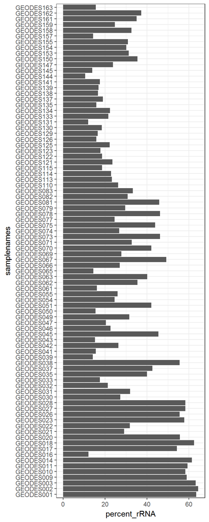

```r
library(ggplot2)
rRNA_ratio <- read.table("C:/Users/Alex/Desktop/geodes/analyses/01rRNA_removal/GEODES_rRNA_ratios.txt", header = F, sep = ",", colClasses = c("character"))
split1 <- strsplit(rRNA_ratio$V1, " ")
split2 <- strsplit(rRNA_ratio$V2, " ")
nonrRNA_count <- c()
rRNA_count <- c()
samplenames <- c()
for(i in 1:length(split1)){
  nonrRNA_count[i] <- split1[[i]][1]
  rRNA_count[i] <- split2[[i]][1]
  samplenames[i] <- substr(split2[[i]][2], start = 1, stop = 9)
}
nonrRNA_count <- as.numeric(nonrRNA_count)/4
rRNA_count <- as.numeric(rRNA_count)/4
percent_rRNA <- rRNA_count/(rRNA_count + nonrRNA_count) * 100
rRNA_ratios <- data.frame(samplenames, percent_rRNA)
ggplot(rRNA_ratios, aes(x = samplenames, y = percent_rRNA)) + theme_bw() + geom_bar(stat = "identity") + coord_flip()
```

On submit-3.chtc.wisc.edu:

```bash
# Delete all the .log, .out, and .err files in your home directory
rm *.err
rm *.log
rm *.out

# Remove the rRNA ratios report and the sample name files
rm *.txt
```

Congratulations! You now have files of just nonrRNA reads from your metatranscriptomes, and are ready to run the next step.

### Lazy Run

You’ve already run the code above and worked out any errors that may arise on a few test files. Or maybe you got everything processed and then received a couple more samples to analyze. Either way, AS LONG AS YOU ARE CONFIDENT THAT THE WORKFLOW WORKS FOR YOUR SAMPLES AND PRODUCEs ABSOLUTELY ZERO ERRORS OR WARNINGS, go ahead and use the lazy run code.

```bash
rm /mnt/gluster/amlinz/GEODES_metaT_split/*
for file in /mnt/gluster/amlinz/GEODES_metaT/*; do sample=$(basename $file |cut -d'.' -f1); echo $sample;done > samplenames.txt
condor_submit submits/00split_fastq.sub
#Wait for all jobs to finish

rm /mnt/gluster/amlinz/GEODES_nonrRNA_split/*
rm /mnt/gluster/amlinz/GEODES_rRNA_split/*
find /mnt/gluster/amlinz/GEODES_metaT_split/ -type f > path2splitfastqs.txt
condor_submit submits/01rRNA_removal.sub
#Wait

condor_submit submits/02cat_files.sub
#Wait

cat *_rRNA_results.txt > GEODES_rRNA_ratios.txt
#Download results
rm *.err
rm *.log
rm *.out
```

# Lab Notebook

#### 2017-02-02

I’ve downloaded the latest precompiled Linux binaries from here: http://bioinfo.lifl.fr/RNA/sortmerna/

Now I want to know where the databases are kept and which ones come preloaded with the install. On my home folder in submit-3.chtc.wisc.edu, I entered:

```bash
tar -xvf sortmerna-2.1-linux-64.tar.gz
```

They are located in sortmerna/rRNA_databases/ , and looks everything I need.

The steps my executable will need to perform are:

1. Get a fastq file from gluster (the place to hold giant files on our high throughput computing system)
2. Unzip the fastq file
3. Unzip the sortmerna program file
4. Index the databases
5. Run sortmerna
6. Transfer output files back to gluster
7. Remove all files transferred from gluster

Here’s my first stab at the executable. Just running on one fastq file for now.

```bash
#!/bin/bash
#Sort metatranscriptomic reads into rRNA and non-rRNA files
#Starting with one fastq file for now

#Transfer the fasta file from gluster
cp /mnt/gluster/amlinz/GEODES_metaT/GEODES001.filter-MTF.fastq.gz ./

#Unzip files
gzip -d GEODES001.filter-MTF.fastq.gz
tar -xvf sortmerna-2.1-linux-64.tar.gz

cd sortmerna-2.1-linux-64

#Index the rRNA databases
./indexdb_rna --ref ./rRNA_databases/silva-bac-16s-id90.fasta,./index/silva-bac$
./rRNA_databases/silva-bac-23s-id98.fasta,./index/silva-bac-23s-db:\
./rRNA_databases/silva-arc-16s-id95.fasta,./index/silva-arc-16s-db:\
./rRNA_databases/silva-arc-23s-id98.fasta,./index/silva-arc-23s-db:\
./rRNA_databases/silva-euk-18s-id95.fasta,./index/silva-euk-18s-db:\
./rRNA_databases/silva-euk-28s-id98.fasta,./index/silva-euk-28s:\
./rRNA_databases/rfam-5s-database-id98.fasta,./index/rfam-5s-db:\
./rRNA_databases/rfam-5.8s-database-id98.fasta,./index/rfam-5.8s-db

#Run the sorting program
./sortmerna --ref ./rRNA_databases/silva-bac-16s-id90.fasta,./index/silva-bac-1$
./rRNA_databases/silva-bac-23s-id98.fasta,./index/silva-bac-23s-db:\
./rRNA_databases/silva-arc-16s-id95.fasta,./index/silva-arc-16s-db:\
./rRNA_databases/silva-arc-23s-id98.fasta,./index/silva-arc-23s-db:\
./rRNA_databases/silva-euk-18s-id95.fasta,./index/silva-euk-18s-db:\
./rRNA_databases/silva-euk-28s-id98.fasta,./index/silva-euk-28s:\
./rRNA_databases/rfam-5s-database-id98.fasta,./index/rfam-5s-db:\
./rRNA_databases/rfam-5.8s-database-id98.fasta,./index/rfam-5.8s-db\
--reads ./GEODES001.filter-MTF.fastq  --fastx --aligned GEODES001_rRNA\
--other GEODES002_nonrRNA --log -v -m 3

#Let's unpack the parameters I've chosen. --ref refers to the databases I've just indexed. --reads says use the fastq file provided. --fastx means I would like a fastq file as output. --aligned is the name for rRNA reads, --other is the name for non-rRNA reads. --log says compute statistics about the run. -v means verbose. I've left the alignment setting at the default, --best. There's a faster setting, but I'm hoping I won't need it. And finally, -m tells sortmerna it can use 3GB of RAM to hold each piece of the fastq file as it processes. Hopefully that will give it a fighting chance

#Move the output files back to gluster
mv GEODES001_rRNA.fastq /mnt/gluster/amlinz/GEODES_rRNA
mv GEODES001_nonrRNA.fastq /mnt/gluster/amlinz/GEODES_nonrRNA

#Remove files
cd ..
rm GEODES001.filter-MTF.fastq
rm GEODES001.filter-MTF.fastq.gz
rm sortmerna-2.1-linux-64.tar.gz
rm -f sortmerna-2.1-linux-64
```

Saved as 01rRNA_removal.sh Here’s its associated submit file, 01rRNA_removal.sub:

```bash
# 01rRNA_removal.sub
#
#
# Specify the HTCondor Universe
universe = vanilla
log = 01rRNA_removal_$(Cluster).log
error = 01rRNA_removal_$(Cluster)_$(Process).err
#
# Specify your executable, arguments, and a file for HTCondor to store standard
#  output.
executable = 01rRNA_removal.sh
#arguments = $(fastqfile)
output = 01rRNA_removal_$(Cluster).out
#
# Specify that HTCondor should transfer files to and from the
#  computer where each job runs.
should_transfer_files = YES
#when_to_transfer_output = ON_EXIT
transfer_input_files = sortmerna-2.1-linux-64.tar.gz
#transfer_output_files =
#
# Tell HTCondor what amount of compute resources
#  each job will need on the computer where it runs.
Requirements = (Target.HasGluster == true)
request_cpus = 1
request_memory = 4GB
request_disk = 10GB
#
# Tell HTCondor to run every fasta file in the provided list:
#queue fastafile from metagenome_list.txt
queue 1
```

I’ve commented out the options I’ll need later (arguments, queue)

Now the moment of truth. By the way, I’m running things on HTCondor using

```bash
condor_submit 01rRNA_removal.sub
#check status
condor_q
```

Error thrown: I got the help page for sortmerna and the output files weren’t generated, which the flags for that command are wrong. I also got that I can’t remove a directory.

I couldn’t find anything wrong with sortmerna, so I move the commands for ./indexdb and ./sortmerna onto one line, instead of / at the end of each line (like what I copied off the manual). Maybe that doesn’t work in bash scripts. I also changed the removal of the directory to “rm -rf”.

Error again: No help file from sortmerna, but no results either. I realized I was missing a dot in calling the reads file - it should be “–reads ../GEODESetc” instead lf “–reads ./GEODESetc”. I also realized that gzip -d removes the .gz file, which is why I got the error that it didn’t exist when I tried to remove it.

Next run produced nothing - no errors, no writing to the screen, no output files. I think I need to run this on Zissou to do more testing. I need to get all my files up there anyway. Will come back to this later!

#### 2017-02-03

Well, the Zissou test worked great and ran for awhile (2 hours) before I killed it. It was 1/5 done. But everything seems to be in order in the bash script. I suspect it might have died because it was too greedy for RAM - on Zissou it used nearly 40GB, despite the “-m 3” setting, while I’d only requested 4. I’ll also need double the hard drive space - 10GB is enough for the input file, but not the input file + output. I’ll change my request settings and try again. I’m also going to add 10 threads in sortmerna using “-a 10” Request: 10 threads, 25GB RAM, 20GB drive space. No idea how many computers in the network meet that requirement.

#### 2017-02-06

Sucess! (ish) The first run I started last Friday was stuck in the queue for an hour, so I restarted with 5 threads, 10GB RAM, and 18GB drive space. That started right away and finished in about 11 hours. No errors were produced, and the right output ended up on Gluster.

Fun fact: check how many computers can run your job with:

```bash
condor_q -analyze
```

HOWEVER. I’m going to need to run this on 108 metatranscriptomes, and there are not 108 servers that meet my requirements, and 11 hours is a long time. SortmeRNA broke up the files into nearly 1900 pieces, then ran them 5 at a time. In order to increase the number of computers meeting my requirements (and therefore increase speed), I need to split my fastq files into many smaller files. I’ll do this on CHTC as well, and use Grace’s script from https://github.com/dshrade1/Metagenomic-Time-Series-CHTC/blob/master/TE/preprocess/preprocess_fasta.sh as a model. Just doing one file to test for right now.

```bash
#!/bin/bash

cp /mnt/gluster/amlinz/GEODES_metaT/GEODES001.filter-MTF.fastq.gz ./
gzip -d GEODES001.filter-MTF.fastq.gz

# make a folder for each metagenome
code=`echo "$1" | cut -d'.' -f1`
mkdir ${code}

# Split by number of lines
# Each takes up four lines - @HISEQ header, forward read, "+", reverse read. So make sure my line cutoff is a multiple of 4
split -l 1000000 $1 ${code}/${code}

# Grace includes a read file in the folder with the split files, but I don't think that makes sense for using with SortmeRNA
# I'm also not going to zip up the file, because I'd just need to unzip back on gluster
cp ${code} /mnt/amlinz/gluster/GEODES_metaT_split/${code}
rm -r ${code}
rm GEODES001.filter-MTF.fastq
```

And the submit file:

```bash
# 00split_fastq.sub
#
#
# Specify the HTCondor Universe
universe = vanilla
log = 00split_fastq_$(Cluster).log
error = 00split_fastq_$(Cluster)_$(Process).err
#
# Specify your executable, arguments, and a file for HTCondor to store standard
#  output.
executable = 00split_fastq.sh
#arguments = $(fastqfile)
output = 00split_fastq_$(Cluster).out
#
# No files to transfer, since it's going to interact with Gluster instead of the submit node
should_transfer_files = YES
when_to_transfer_output = ON_EXIT
#transfer_input_files =
#transfer_output_files =
#
# Tell HTCondor what amount of compute resources
#  each job will need on the computer where it runs.
# This gives me ~800 target computers
Requirements = (Target.HasGluster == true)
request_cpus = 1
request_memory = 2GB
request_disk = 12GB
#
# Just one job for testing
queue 1
```

I did a little tweaking of naming the output files. Here’s the final version of the executable. I’m debating adding a line to add .fastq to the end of the split files, but will see if sortmerna can figure it out first.

```bash
#!/bin/bash

cp /mnt/gluster/amlinz/GEODES_metaT/GEODES001.filter-MTF.fastq.gz ./
gzip -d GEODES001.filter-MTF.fastq.gz

# make a folder for each metagenome
code=`echo "GEODES001.filter-MTF.fastq" | cut -d'.' -f1`
mkdir ${code}

# Split by number of lines
split -l 1000000 GEODES001.filter-MTF.fastq ${code}/${code}

# Grace includes a read file in the folder with the split files, but I don't think that makes sense for using with SortmeRNA
# I'm also not going to zip up the file, because I'd just need to unzip back on gluster
mv ${code} /mnt/gluster/amlinz/GEODES_metaT_split/
rm GEODES001.filter-MTF.fastq
```

Now to test sortmerna on one of the split files!

New executable:

```bash
#!/bin/bash
#Sort metatranscriptomic reads into rRNA and non-rRNA files
#Starting with one fastq file for now

#Transfer the fasta file from gluster
cp /mnt/gluster/amlinz/GEODES_metaT_split/GEODES001/GEODES001aa ./

#Unzip files
#gzip -d GEODES001.filter-MTF.fastq.gz
tar -xvf sortmerna-2.1-linux-64.tar.gz

cd sortmerna-2.1-linux-64

#Index the rRNA databases
./indexdb_rna --ref ./rRNA_databases/silva-bac-16s-id90.fasta,./index/silva-bac-16s-db:\./rRNA_databases/silva-bac-23s-id98.fasta,./index/silva-bac-23s-db:./rRNA_databases/silva-arc-16s-id95.fasta,./index/silva-arc-16s-db:./rRNA_databases/silva-arc-23s-id98.fasta,./index/silva-arc-23s-db:./rRNA_databases/silva-euk-18s-id95.fasta,./index/silva-euk-18s-db:./rRNA_databases/silva-euk-28s-id98.fasta,./index/silva-euk-28s:./rRNA_databases/rfam-5s-database-id98.fasta,./index/rfam-5s-db:./rRNA_databases/rfam-5.8s-database-id98.fasta,./index/rfam-5.8s-db

#Run the sorting program
./sortmerna --ref ./rRNA_databases/silva-bac-16s-id90.fasta,./index/silva-bac-16s-db:./rRNA_databases/silva-bac-23s-id98.fasta,./index/silva-bac-23s-db:./rRNA_databases/silva-arc-16s-id95.fasta,./index/silva-arc-16s-db:./rRNA_databases/silva-arc-23s-id98.fasta,./index/silva-arc-23s-db:./rRNA_databases/silva-euk-18s-id95.fasta,./index/silva-euk-18s-db:./rRNA_databases/silva-euk-28s-id98.fasta,./index/silva-euk-28s:./rRNA_databases/rfam-5s-database-id98.fasta,./index/rfam-5s-db:./rRNA_databases/rfam-5.8s-database-id98.fasta,./index/rfam-5.8s-db --reads ../GEODES001aa  --fastx --aligned GEODES001_rRNA --other GEODES001_nonrRNA --log -v -m 3 -a 10

#Let's unpack the parameters I've chosen. --ref refers to the databases I've just indexed. --reads says use the fastq file provided. --fastx means I would like a fastq file as output. --aligned is the name for rRNA reads, --other is the name for non-rRNA reads. --log says compute statistics about the run. -v means verbose. I've left the alignment setting at the default, --best. There's a faster setting, but I'm hoping I won't need it. And finally, -m tells sortmerna it can use 3GB of RAM to hold each piece of the fastq file as it processes. Hopefully that will give it a fighting chance.
#Move the output files back to gluster
mv GEODES001aa_rRNA.fastq /mnt/gluster/amlinz/GEODES_rRNA/
mv GEODES001aa_nonrRNA.fastq /mnt/gluster/amlinz/GEODES_nonrRNA/

#Remove files
cd ..
rm GEODES001aa
rm sortmerna-2.1-linux-64.tar.gz
rm -r sortmerna-2.1-linux-64
```

Submit file is the same except changed requirements - 10 threads, 3GB RAM, 5GB drive space

Sortmerna has no problem running on the file without the fastq extension, but I’m having trouble moving the output to gluster. Moving to Zissou to find out what the output file names should be.

Turns out the error was because there was no .fastq extension.

I added:

```bash
# Rename files to include .fastq extension
for file in ${code}/*;do mv "$file" "$file.fastq";done
```

Note: code will break if there’s already a folder named GEODES001 in the sample place. Delete old run outputs before rerunning.

Looks like everything worked! My next goal is to run the rRNA sorting script on all the pieces of GEODES001.

#### 2017-02-07

First things first, let’s make a list of the files to run:

```bash
find /mnt/gluster/amlinz/GEODES_metaT_split/ -type f > path2splitfastqs.txt
```

Now modify the submit file to read from that list:

```bash
# 01rRNA_removal.sub
#
#
# Specify the HTCondor Universe
universe = vanilla
log = 01rRNA_removal_$(Cluster).log
error = 01rRNA_removal_$(Cluster)_$(Process).err
#
# Specify your executable, arguments, and a file for HTCondor to store standard
#  output.
executable = 01rRNA_removal.sh
arguments = $(fastqfile)
output = 01rRNA_removal_$(Cluster).out
#
# Specify that HTCondor should transfer files to and from the
#  computer where each job runs.
should_transfer_files = YES
when_to_transfer_output = ON_EXIT
transfer_input_files = sortmerna-2.1-linux-64.tar.gz
#transfer_output_files =
#
# Tell HTCondor what amount of compute resources
#  each job will need on the computer where it runs.
Requirements = (Target.HasGluster == true)
request_cpus = 1
request_memory = 2GB
request_disk = 5GB
#
# Tell HTCondor to run every fastq file in the provided list:
queue fastqfile from path2splitfastqs.txt
```

And add the $1 argument variable to the executable:

```bash
#!/bin/bash
#Sort metatranscriptomic reads into rRNA and non-rRNA files

#Transfer the fasta file from gluster
cp $1 ./
name=$(basename '$1' |cut -d'.' -f1)

#Unzip files
tar -xvf sortmerna-2.1-linux-64.tar.gz

cd sortmerna-2.1-linux-64

#Index the rRNA databases
./indexdb_rna --ref ./rRNA_databases/silva-bac-16s-id90.fasta,./index/silva-bac-16s-db:\./rRNA_databases/silva-bac-23s-id98.fasta,./index/silva-bac-23s-db:./rRNA_databases/silva-arc-16s-id95.fasta,./index/silva-arc-16s-db:./rRNA_databases/silva-arc-23s-id98.fasta,./index/silva-arc-23s-db:./rRNA_databases/silva-euk-18s-id95.fasta,./index/silva-euk-18s-db:./rRNA_databases/silva-euk-28s-id98.fasta,./index/silva-euk-28s:./rRNA_databases/rfam-5s-database-id98.fasta,./index/rfam-5s-db:./rRNA_databases/rfam-5.8s-database-id98.fasta,./index/rfam-5.8s-db

#Run the sorting program
./sortmerna --ref ./rRNA_databases/silva-bac-16s-id90.fasta,./index/silva-bac-16s-db:./rRNA_databases/silva-bac-23s-id98.fasta,./index/silva-bac-23s-db:./rRNA_databases/silva-arc-16s-id95.fasta,./index/silva-arc-16s-db:./rRNA_databases/silva-arc-23s-id98.fasta,./index/silva-arc-23s-db:./rRNA_databases/silva-euk-18s-id95.fasta,./index/silva-euk-18s-db:./rRNA_databases/silva-euk-28s-id98.fasta,./index/silva-euk-28s:./rRNA_databases/rfam-5s-database-id98.fasta,./index/rfam-5s-db:./rRNA_databases/rfam-5.8s-database-id98.fasta,./index/rfam-5.8s-db --reads ../${name}.fastq  --fastx --aligned ${name}_rRNA --other ${name}_nonrRNA --log -v -m 1 -a 1

#Let's unpack the parameters I've chosen. --ref refers to the databases I've just indexed. --reads says use the fastq file provided. --fastx means I would like a fastq file as output. --aligned is the name for rRNA reads, --other is the name for non-rRNA reads. --log says compute statistics about the run. -v means verbose. I've left the alignment setting at the default, --best. There's a faster setting, but I'm hoping I won't need it. And finally, -m tells sortmerna it can use 3GB of RAM to hold each piece of the fastq file as it processes. Hopefully that will give it a fighting chance.
#Move the output files back to gluster
mv ${name}_rRNA.fastq /mnt/gluster/amlinz/GEODES_rRNA/
mv ${name}_nonrRNA.fastq /mnt/gluster/amlinz/GEODES_nonrRNA/

#Remove files
cd ..
rm ${name}.fastq
rm sortmerna-2.1-linux-64.tar.gz
rm -r sortmerna-2.1-linux-64
```

I’m going to try running this on just three files to start:

```bash
head -3 path2splitfastqs.txt > test_path2splitfastqs.txt
```

Looking good! In fact, I can drop my memory requirements down to 1GB RAM and 2GB drive space.

Now one last script - putting the files back together. I’ll need to copy all of the files from each GEODES number to a server, concatenate them, and send it back to gluster.

This line makes a file of all of the sample nams:

```bash
for file in /mnt/gluster/amlinz/GEODES_metaT/*; do sample=$(basename $file |cut -d'.' -f1); echo $sample;done > samplenames.txt

head -1 samplenames.txt > test_samplenames.txt
```

First stab at the executable:

```bash
#!/bin/bash
#Concatenate sortmerna output

cp /mnt/gluster/amlinz/GEODES_nonrRNA/$1??_nonrRNA.fastq ./
cat $1??_nonrRNA.fastq > $1_nonrRNA.fastq
mv $1_nonrRNA.fastq /mnt/gluster/amlinz/GEODES_nonrRNA_concat/
rm *_nonrRNA.fastq

cp /mnt/gluster/amlinz/GEODES_rRNA/$1*??_rRNA.fastq ./
cat $1??_rRNA.fastq > $1_rRNA.fastq
mv $1_rRNA.fastq /mnt/gluster/amlinz/GEODES_rRNA_concat/
rm *_rRNA.fastq
```

And the submit file:

```bash
# 02cat_files.sub
#
#
# Specify the HTCondor Universe
universe = vanilla
log = 02cat_files_$(Cluster).log
error = 02cat_files_$(Cluster)_$(Process).err
#
# Specify your executable, arguments, and a file for HTCondor to store standard
#  output.
executable = 02cat_files.sh
arguments = $(sample)
output = 02cat_files_$(Cluster).out
#
# Specify that HTCondor should transfer files to and from the
#  computer where each job runs.
should_transfer_files = YES
when_to_transfer_output = ON_EXIT
#transfer_input_files =
#transfer_output_files =
#
# Tell HTCondor what amount of compute resources
#  each job will need on the computer where it runs.
Requirements = (Target.HasGluster == true)
request_cpus = 1
request_memory = 10GB
request_disk = 10GB
#
# Tell HTCondor to run every fastq file in the provided list:
queue sample from test_samplenames.txt
```

I got an error from cat saying “input file is output file”. I added ?? characters to the selection of file names to specify that I want GEODES001ae_nonrRNA.fastq, not GEODES001_nonrRNA.fastq.

That worked! Now I know I said that was the last process, but there’s something else I want. I want to know the ratio of nonrRNA to rRNA reads for each sample. I can add that to the above script, and also zip the files up when I’m done. I’ve add the output file $1_rRNA_results.txt to transfer_output in .sub.

New executable:

```bash
#!/bin/bash
#Concatenate sortmerna output

cp /mnt/gluster/amlinz/GEODES_nonrRNA/$1??_nonrRNA.fastq ./
cat $1??_nonrRNA.fastq > $1_nonrRNA.fastq
nonrRNAcount=$(wc -l $1_nonrRNA.fastq)
gzip $1_nonrRNA.fastq
mv $1_nonrRNA.fastq.gz /mnt/gluster/amlinz/GEODES_nonrRNA_concat/
rm *_nonrRNA.fastq

cp /mnt/gluster/amlinz/GEODES_rRNA/$1*??_rRNA.fastq ./
cat $1??_rRNA.fastq > $1_rRNA.fastq
rRNAcount=$(wc -l $1_rRNA.fastq)
gzip $1_rRNA.fastq
mv $1_rRNA.fastq.gz /mnt/gluster/amlinz/GEODES_rRNA_concat/
rm *_rRNA.fastq

echo ${nonrRNAcount},${rRNAcount} > $1_rRNA_results.txt
```

Alright! I’m going to clean up my directories, then rerun all scripts on 3 samples. I’ll document everything at the top “most recent workflow” section so that I’ll be ready to go when I have all of the data downloaded (hopefully tomorrow!)

#### 2017-02-08

Everything great on the three samples, except for 3 samples getting stuck in infinite run time. I asked Christina at CHTC about this and she said that just happens sometimes. In that case, I can stop and restart the runs with:

```bash
condor_q -run -nobatch # Check to see whate server they're on
condor_hold amlinz # Move all my jobs to holding
condor_release amlinz # Start all jobs that are in holding
```

After that it was all peachy, right up until I wiped my home folder clean with a bad rm command *sigh*. Luckily I’d downloaded all my scripts to my github repo, but I lost a couple minor changes. For posterity, here’s the FINAL FINAL versions of the scripts. I’m testing these on one more sample while I’m downloading the remaining fastq files from the JGI portal.

New fun fact: Since I saved my files on a Windows machine, they got new line endings and won’t run. Fix using:

```bash
dos2unix *.sh
dos2unix *.sub
```

I love Windows.

00split_fastq.sh:

```bash
#!/bin/bash

cp /mnt/gluster/amlinz/GEODES_metaT/$1.filter-MTF.fastq.gz ./
gzip -d $1.filter-MTF.fastq.gz

# make a folder for each metagenome
mkdir $1

# Split by number of lines
split -l 1000000 $1.filter-MTF.fastq $1/$1

# Rename files to include .fastq extension
for file in $1/*;do mv "$file" "$file.fastq";done

# Grace includes a read file in the folder with the split files, but I don't think that makes sense for using with SortmeRNA
# I'm also not going to zip up the file, because I'd just need to unzip back on gluster
mv $1 /mnt/gluster/amlinz/GEODES_metaT_split/
rm $1.filter-MTF.fastq
```

00split_fastq.sub:

```bash
# 00split_fastq.sub
#
#
# Specify the HTCondor Universe
universe = vanilla
log = 00split_fastq_$(Cluster).log
error = 00split_fastq_$(Cluster)_$(Process).err
#
# Specify your executable, arguments, and a file for HTCondor to store standard
#  output.
executable = 00split_fastq.sh
arguments = $(sample)
output = 00split_fastq_$(Cluster).out
#
# No files to transfer, since it's going to interact with Gluster instead of the submit node
should_transfer_files = YES
when_to_transfer_output = ON_EXIT
#transfer_input_files =
#transfer_output_files =
#
# Tell HTCondor what amount of compute resources
#  each job will need on the computer where it runs.
Requirements = (Target.HasGluster == true)
request_cpus = 1
request_memory = 2 GB
request_disk = 12 GB
#
# Just one job for testing
queue sample from samplenames.txt
```

01rRNA_removal.sh:

```bash
#!/bin/bash
#Sort metatranscriptomic reads into rRNA and non-rRNA files

#Transfer the fasta file from gluster
cp $1 ./
name=$(basename $1 |cut -d'.' -f1)

#Unzip files
tar -xvf sortmerna-2.1-linux-64.tar.gz

cd sortmerna-2.1-linux-64

#Index the rRNA databases
./indexdb_rna --ref ./rRNA_databases/silva-bac-16s-id90.fasta,./index/silva-bac-16s-db:\./rRNA_databases/silva-bac-23s-id98.fasta,./index/silva-bac-23s-db:./rRNA_databases/silva-arc-16s-id95.fasta,./index/silva-arc-16s-db:./rRNA_databases/silva-arc-23s-id98.fasta,./index/silva-arc-23s-db:./rRNA_databases/silva-euk-18s-id95.fasta,./index/silva-euk-18s-db:./rRNA_databases/silva-euk-28s-id98.fasta,./index/silva-euk-28s:./rRNA_databases/rfam-5s-database-id98.fasta,./index/rfam-5s-db:./rRNA_databases/rfam-5.8s-database-id98.fasta,./index/rfam-5.8s-db

#Run the sorting program
./sortmerna --ref ./rRNA_databases/silva-bac-16s-id90.fasta,./index/silva-bac-16s-db:./rRNA_databases/silva-bac-23s-id98.fasta,./index/silva-bac-23s-db:./rRNA_databases/silva-arc-16s-id95.fasta,./index/silva-arc-16s-db:./rRNA_databases/silva-arc-23s-id98.fasta,./index/silva-arc-23s-db:./rRNA_databases/silva-euk-18s-id95.fasta,./index/silva-euk-18s-db:./rRNA_databases/silva-euk-28s-id98.fasta,./index/silva-euk-28s:./rRNA_databases/rfam-5s-database-id98.fasta,./index/rfam-5s-db:./rRNA_databases/rfam-5.8s-database-id98.fasta,./index/rfam-5.8s-db --reads ../${name}.fastq  --fastx --aligned ${name}_rRNA --other ${name}_nonrRNA --log -v -m 1 -a 1

#Let's unpack the parameters I've chosen. --ref refers to the databases I've just indexed. --reads says use the fastq file provided. --fastx means I would like a fastq file as output. --aligned is the name for rRNA reads, --other is the name for non-rRNA reads. --log says compute statistics about the run. -v means verbose. I've left the alignment setting at the default, --best. There's a faster setting, but I'm hoping I won't need it. And finally, -m tells sortmerna it can use 3GB of RAM to hold each piece of the fastq file as it processes. Hopefully that will give it a fighting chance.
#Move the output files back to gluster
mv ${name}_rRNA.fastq /mnt/gluster/amlinz/GEODES_rRNA/
mv ${name}_nonrRNA.fastq /mnt/gluster/amlinz/GEODES_nonrRNA/

#Remove files
cd ..
rm ${name}.fastq
rm sortmerna-2.1-linux-64.tar.gz
rm -r sortmerna-2.1-linux-64
```

01rRNA_removal.sub

```bash
# 01rRNA_removal.sub
#
#
# Specify the HTCondor Universe
universe = vanilla
log = 01rRNA_removal_$(Cluster).log
error = 01rRNA_removal_$(Cluster)_$(Process).err
#
# Specify your executable, arguments, and a file for HTCondor to store standard
#  output.
executable = 01rRNA_removal.sh
arguments = $(fastqfile)
output = 01rRNA_removal_$(Cluster).out
#
# Specify that HTCondor should transfer files to and from the
#  computer where each job runs.
should_transfer_files = YES
when_to_transfer_output = ON_EXIT
transfer_input_files = sortmerna-2.1-linux-64.tar.gz
#transfer_output_files =
#
# Tell HTCondor what amount of compute resources
#  each job will need on the computer where it runs.
Requirements = (Target.HasGluster == true)
request_cpus = 1
request_memory = 2GB
request_disk = 5GB
#
# Tell HTCondor to run every fastq file in the provided list:
queue fastqfile from path2splitfastqs.txt
```

02cat_files.sh:

```bash
#!/bin/bash
#Concatenate sortmerna output

cp /mnt/gluster/amlinz/GEODES_nonrRNA/$1??_nonrRNA.fastq ./
cat $1??_nonrRNA.fastq > $1_nonrRNA.fastq
nonrRNAcount=$(wc -l $1_nonrRNA.fastq)
gzip $1_nonrRNA.fastq
mv $1_nonrRNA.fastq.gz /mnt/gluster/amlinz/GEODES_nonrRNA_concat/
rm *_nonrRNA.fastq

cp /mnt/gluster/amlinz/GEODES_rRNA/$1*??_rRNA.fastq ./
cat $1??_rRNA.fastq > $1_rRNA.fastq
rRNAcount=$(wc -l $1_rRNA.fastq)
gzip $1_rRNA.fastq
mv $1_rRNA.fastq.gz /mnt/gluster/amlinz/GEODES_rRNA_concat/
rm *_rRNA.fastq

echo ${nonrRNAcount},${rRNAcount} > $1_rRNA_results.txt
```

02cat_files.sub

```bash
# 02cat_files.sub
#
#
# Specify the HTCondor Universe
universe = vanilla
log = 02cat_files_$(Cluster).log
error = 02cat_files_$(Cluster)_$(Process).err
#
# Specify your executable, arguments, and a file for HTCondor to store standard
#  output.
executable = 02cat_files.sh
arguments = $(sample)
output = 02cat_files_$(Cluster).out
#
# Specify that HTCondor should transfer files to and from the
#  computer where each job runs.
should_transfer_files = YES
when_to_transfer_output = ON_EXIT
#transfer_input_files =
#transfer_output_files = $(sample)_rRNA_results.txt
#
# Tell HTCondor what amount of compute resources
#  each job will need on the computer where it runs.
Requirements = (Target.HasGluster == true)
request_cpus = 1
request_memory = 10GB
request_disk = 10GB
#
# Tell HTCondor to run every fastq file in the provided list:
queue sample from samplenames.txt
```

Everything looks ready for the full run now! I’m just waiting on the file upload to gluster. It’ll take at least the rest of the night, so I’ll plan on starting in the morning.

#### 2017-02-09

Off we go! Everything finished downloading around 10 this morning. Got the first step started at 10:35. I’m currently running on 85 samples. (The remaining 23 are still being sequenced or processed)

2 got stuck, and produced errors that there was their output already existed in gluster, but everything looks fine so I’ll carry on. For reference, those two errors were from GEODES050 and GEODES154. Total time: 3 hours.

#### 2017-02-10

7,986 finished in 4.5 hours. 1 got stuck and produced error to that effect. I restarted it this morning. I’m a bit concerned about the errors from the last step about output already existing, and that happening during the rRNA run as well. For a preliminary analysis, this doesn’t matter too much, but I’ll look into preventing clashing of jobs that needed a restart in the future. Is there a way to tell the “mv” command to overwrite an existing file of the same name?

A quick Google search suggests either a cp and rm combo, or using rsync. I’ll keep this in mind in the future.

That last job from 01rRNA_removal finally finished! (9:30AM) I have 3 errors - one segmentation (likely the fault of a computer running the job) and two that say the fastq file has uneven lines. I’ll need to look into this, too - maybe I can use a program for splitting fastq files specifically? Like the fastx-toolkit or something? Might be a question for lab meeting.

No errors on the 02cat_files script, hooray! Copying rRNA and nonrRNA zipped files over to Zissou now, and then over to my hard drive.

#### 2017-02-13

Happy Monday! I got everything back up on Zissou and my hard drive over the weekend. The last thing I want to do before closing out this analysis is check that my rRNA/mRNA ratios are similar to those measured by the JGI. I saved the number of lines in each file and will calculate that here.

NOTE: removed this plot after I reran the rRNA removal on 3/15. Check that entry in the lab notebook.

#### 2017-03-10

I found that some of my fastq files had blank lines in the mapping step, and wrote a new splitting script using getreads.sh instead of splitting by line number. See the mapping lab notebook for details. Here’s the new submit and executable files.

```bash
# 00split_fastq.sub
#
#
# Specify the HTCondor Universe
universe = vanilla
log = 00split_fastq_$(Cluster).log
error = 00split_fastq_$(Cluster)_$(Process).err
#
# Specify your executable, arguments, and a file for HTCondor to store standard
#  output.
executable = executables/00split_fastq.sh
arguments = $(sample)
output = 00split_fastq_$(Cluster).out
#
# No files to transfer, since it's going to interact with Gluster instead of th$
should_transfer_files = YES
when_to_transfer_output = ON_EXIT
transfer_input_files = zipped/BBMap_36.99.tar.gz
#transfer_output_files =
#
# Tell HTCondor what amount of compute resources
#  each job will need on the computer where it runs.
Requirements = (Target.HasGluster == true)
request_cpus = 1
request_memory = 2 GB
request_disk = 12 GB
#
# Just one job for testing
queue sample from samplenames.txt
```

```bash
#!/bin/bash
tar -xvzf BBMap_36.99.tar.gz

cp /mnt/gluster/amlinz/GEODES_metaT/$1.filter-MTF.fastq.gz .
gzip -d $1.filter-MTF.fastq.gz

sed -i '/^$/d' $1.filter-MTF.fastq

maxreads=$((`wc -l < $1.filter-MTF.fastq` / 8 - 1))
startpoints=$(seq 0 500000 $maxreads)

for num in $startpoints;
  do endpoint=$(($num + 499999));
  bbmap/getreads.sh in=$1.filter-MTF.fastq id=$num-$endpoint out=$1_filter-MTF_$endpoint.fastq overwrite=T;
  done

rm $1.filter-MTF.fastq
gzip $1*
cp $1* /mnt/gluster/amlinz/GEODES_metaT_split
rm $1*
rm BBMap_36.99.tar.gz
rm -r bbmap
```

#### 2017-03-13

The scripts above seemed to be actually running, but not saving the output in the right place. I’m going to try it in interactive mode to work out the issue.

Got that worked out, plus a directory error in 02catfiles.sh. Going to start the full run now.

#### 2017-03-15

All done! The fastq splitting ran overnight on the 13th, the rRNA sorting ran during the day yesterday, and the file concatenation ran overnight last night. Everything looks good - full files, right number of files, and no errors! I’m confident in this analysis and will move on to the mapping now.

But first, I should double check the rRNA/nonrRNA ratios.

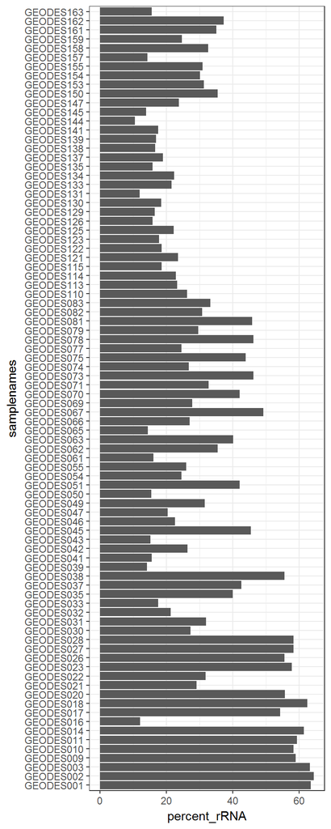

```r
library(ggplot2)
rRNA_ratio <- read.table("C:/Users/Alex/Desktop/geodes/analyses/01rRNA_removal/GEODES_rRNA_ratios.txt", header = F, sep = ",", colClasses = c("character"))
split1 <- strsplit(rRNA_ratio$V1, " ")
split2 <- strsplit(rRNA_ratio$V2, " ")
nonrRNA_count <- c()
rRNA_count <- c()
samplenames <- c()
for(i in 1:length(split1)){
  nonrRNA_count[i] <- split1[[i]][1]
  rRNA_count[i] <- split2[[i]][1]
  samplenames[i] <- substr(split2[[i]][2], start = 1, stop = 9)
}
nonrRNA_count <- as.numeric(nonrRNA_count)/4
rRNA_count <- as.numeric(rRNA_count)/4
percent_rRNA <- rRNA_count/(rRNA_count + nonrRNA_count) * 100
rRNA_ratios <- data.frame(samplenames, percent_rRNA)
ggplot(rRNA_ratios, aes(x = samplenames, y = percent_rRNA)) + theme_bw() + geom_bar(stat = "identity") + coord_flip()
```